# Getting started with the nh3pred package

## Overview

The package exposes one user-facing function, `predict`. It predicts ammonia emission dynamics following fertilizer application. The model is a recurrent neural network trained on the ALFAM2 database ([Hafner et al., 2018](https://doi.org/10.1016/j.agrformet.2017.11.027) ; [Hafner et al., 2025](https://doi.org/10.1016/j.atmosenv.2024.120910)). See here for a full description of the model.

This guide covers the three most common workflows:

1. predicting from plot-level data only;
2. supplying a custom time and weather table;
3. comparing several application scenarios.

## Import the package

```python
import matplotlib.pyplot as plt
import pandas as pd

from nh3pred import predict
```

## Minimal prediction

`pdat` contains one row per field application. The `id` column uniquely identifies each application and links it to optional time-dependent data.

Only the variables needed to describe this example are supplied below. All other variables are completed with package defaults.

```python
pdat = pd.DataFrame(
    {
        "id": [1],
        "tan_app": [70],
        "app_method": ["bc"],
    }
)

predictions = predict(pdat)
```

When `idat` is omitted, predictions use cumulative times 2, 4, and then four-hour intervals from 4 to 48 h, and twelve-hour intervals from 48 to 240 h. The package uses a repeating default daily temperature and wind profile and assumes no rainfall.

```python
predictions[
    [
        "id",
        "ct",
        "air_temp",
        "wind_2m",
        "prediction_erel",
        "prediction_ecum",
    ]
].head()
```

|  | id | ct | air_temp | wind_2m | prediction_erel | prediction_ecum |
| --- | --- | --- | --- | --- | --- | --- |
| 0 | 1 | 2 | 16.29 | 3.31 | 0.07 | 4.56 |
| 1 | 1 | 4 | 18.54 | 3.85 | 0.14 | 9.88 |
| 2 | 1 | 8 | 19.83 | 4.16 | 0.28 | 19.69 |
| 3 | 1 | 12 | 16.29 | 3.31 | 0.39 | 27.03 |
| 4 | 1 | 16 | 11.46 | 2.15 | 0.46 | 31.91 |

## Plot the prediction

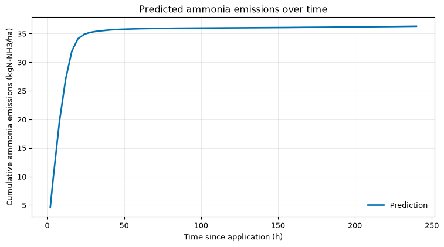

```python
fig, ax = plt.subplots(figsize=(8, 4.5))
ax.plot(
    predictions["ct"],
    predictions["prediction_ecum"],
    color="#0072B2",
    linewidth=2,
    label="Prediction",
)
ax.set(
    xlabel="Time since application (h)",
    ylabel="Cumulative ammonia emissions (kgN-NH3/ha)",
    title="Predicted ammonia emissions over time",
)
ax.grid(alpha=0.25)
ax.legend(frameon=False)
fig.tight_layout()
plt.show()
```

## Supply custom time and weather data

`idat` contains one row per application and time point. Time points may be irregular. In this example, air temperature is supplied while wind and rainfall are omitted.

```python
idat = pd.DataFrame(
    {
        "id": [1, 1, 1, 1, 1],
        "ct": [2, 8, 20, 32, 48],
        "air_temp": [16, 21, 13, 15, 18],
    }
)

custom_predictions = predict(pdat, idat)

custom_predictions[
    ["id", "ct", "air_temp", "wind_2m", "rain_rate", "prediction_ecum"]
]
```

|  | id | ct | air_temp | wind_2m | rain_rate | prediction_ecum |
| --- | --- | --- | --- | --- | --- | --- |
| 0 | 1 | 2 | 16 | 3.31 | 0 | 4.55 |
| 1 | 1 | 8 | 21 | 4.16 | 0 | 18.88 |
| 2 | 1 | 20 | 13 | 1.84 | 0 | 37.49 |
| 3 | 1 | 32 | 15 | 4.16 | 0 | 45.71 |
| 4 | 1 | 48 | 18 | 2.69 | 0 | 50.14 |

User-supplied columns are preserved. A missing `air_temp` or `wind_2m` column is filled by interpolating the corresponding default profile at the requested `ct` values. Missing rainfall variables default to zero.

## Compare several scenarios

Each row of `pdat` may describe a different scenario. Here, three applications differ only in application method.

```python
scenario_pdat = pd.DataFrame(
    {
        "id": [1, 2, 3],
        "tan_app": [70, 70, 70],
        "app_method": ["bc", "ts", "os"],
    }
)

scenario_predictions = predict(scenario_pdat)

scenario_predictions.groupby("id", as_index=False).tail(1)[
    ["id", "ct", "app_method", "prediction_ecum"]
]
```

|  | id | ct | app_method | prediction_ecum |
| --- | --- | --- | --- | --- |
| 28 | 1 | 240 | bc | 36.29 |
| 57 | 2 | 240 | ts | 21.17 |
| 86 | 3 | 240 | os | 8.21 |

See the scenario comparison vignette for a complete visual comparison.

## Control computation time

```python
predictions = predict(
    pdat,
    idat,
    batch_size=128,
)
```

- `batch_size` controls how many application sequences are processed together. Larger values may improve speed but require more memory.

## Next steps

Consult the input reference for all accepted columns, default values, and information on predictor distributions in the training data. Predictions outside the ranges represented in the training data should be interpreted cautiously.